# Final Project: R Reference

### Boxplot [boxplot( )]

We can create boxplots with boxplot( ). Similar to histograms, we really only need the data we want to plot for boxplots. However, we can also explore conditional boxplots by using the tilde (~) to condition a variable on another in our data.

In the below examples, we explore a boxplot with a single variable and a conditional box plot:

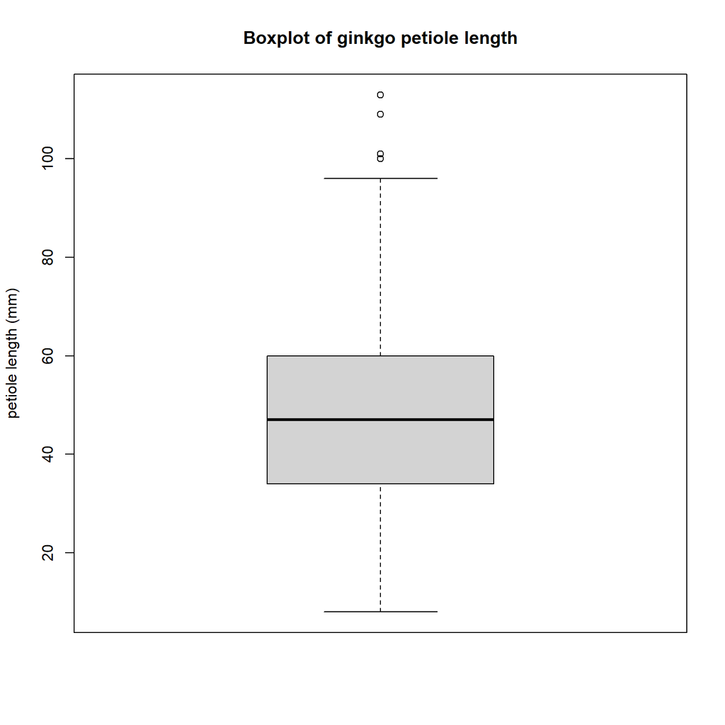

```r
## Create boxplot of a single variable:

boxplot(dat_ginkgo$petiole_length,
        main = "Boxplot of ginkgo petiole length",
        ylab = "petiole length (mm)")
```

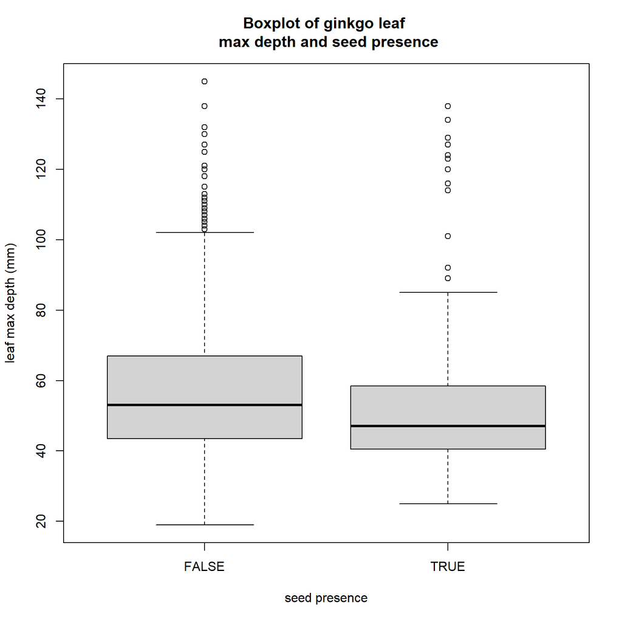

```r
## Create a conditional boxplot:
boxplot(dat_ginkgo$max_depth ~ dat_ginkgo$seeds_present,
        main = "Boxplot of ginkgo leaf \n max depth and seed presence",
        ylab = "leaf max depth (mm)",
        xlab = "seed presence")
```

### Paneled Figures [par( )]

In addition to creating single figures, we can also combine graphs into a paneled figure by using par( ). Par( ) has a required argument:

- mfrow - used to determine the number of rows and columns that the graphs are distributed across, e.g. c(1, 3)

To create the paneled figure, we also need to make sure that par( ) is included in the R code prior to creating the histograms.

Below, I will show an example of this by creating four histograms with the Adelie penguins dataset previously created:

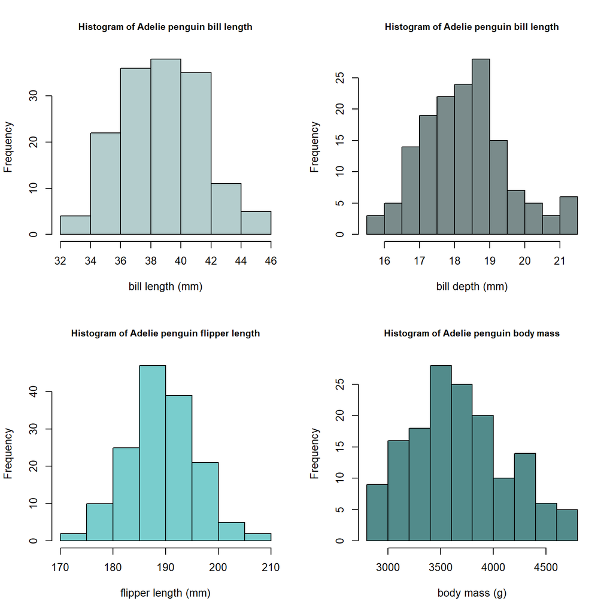

```r
par(mfrow = c(2, 2))

hist(dat_adelie$bill_length_mm,
     main = "Histogram of Adelie penguin bill length",
     xlab = "bill length (mm)", col = "lightcyan3",
     cex.main = 0.85)

hist(dat_adelie$bill_depth_mm,
     main = "Histogram of Adelie penguin bill length",
     xlab = "bill depth (mm)", col = "lightcyan4",
     cex.main = 0.85)

hist(dat_adelie$flipper_length_mm,
     main = "Histogram of Adelie penguin flipper length",
     xlab = "flipper length (mm)", col = "darkslategray3",
     cex.main = 0.85)

hist(dat_adelie$body_mass_g,
     main = "Histogram of Adelie penguin body mass",
     xlab = "body mass (g)", col = "darkslategray4",
     cex.main = 0.85)
```

## Distribution Functions

R implements probability, cumulative probability, and quantile functions for many distributions, including parametric and normal distributions.

### Normal Distributions

Normal distribution is a continuous distribution and normal distribution functions include the following:

- dnorm( ) is the probability density function for a normal distribution
- pnorm( ) is the cumulative density function
- qnorm( ) is the quantile function

The continuous distribution uses the term density rather than mass (as used in discrete distributions).

#### dnorm( )

```r
dnorm(7, mean = 10, sd = 2.5)
```

```
## [1] 0.07767442
```

#### pnorm( )

```r
pnorm(7, mean = 10, sd = 2.5)
```

```
## [1] 0.1150697
```

These results indicate that we have approximately a 11.5% chance to observe a value of 7 or less. But what if we wanted to know the probability of observing the value of greater than 7? We can figure that out by subtracting probability of observing a value of 7 or less from 1. Here is an example of that:

```r
1 - pnorm(7, mean = 10, sd = 2.5)
```

```
## [1] 0.8849303
```

So in this case we have approximately an 88.5% chance to observe a value greater than 7.

#### qnorm( )

Like dnorm( ) and pnorm( ), we can calculate the quantile function of a vector of probabilities. However, with qnorm( ) we will find the boundary value or the quantile/percentile of the area. So essentially, this is the value in which a certain percentile, e.g. 75%, of a population that is normally distributed will fall below.

In the example below, I will show how to use qnorm if we want to find the 85th percentile value:

```r
qnorm(0.85, mean = 10, sd = 2.5)
```

```
## [1] 12.59108
```

In our example above, we can say that 85% of the values in a population that is normally distributed with a mean of 10 and sd of 2.5 will fall below 12.59108.

### Discrete Distributions

Similar to the normal distribution, we can use various functions to calculate the probability, cumulative probability, and quantile function of a binomial distribution. Binomial distribution is a discrete distribution and binomial distribution functions include the following

- dbinom( ) is the probability mass function for a binomial distribution
- pbinom ) is the cumulative mass function
- qbinom( ) is the quantile function

#### dbinom( )

The dbinom( ) function gives us the mass of a binomial distribution. We would use dbinom( ) to calculate the probability that we observe an exact count of successes based on a sample parameter, a size (total samples possible), and a probability parameter.

In the below example, I will show how to calculate the dbinom( ) probability of observing birds in 10 of the 15 plots I collected data in a binomial distribution with a probability of 10/15 or 2/3 or 0.666666.

```r
dbinom(x = 10, size = 15, prob = 2/3, log = FALSE)
```

```
## [1] 0.2143071
```

So, these results indicate that I would observe birds in 10 of the 15 plots approximately 21 % of the time.

#### pbinom( )

Similar to pnorm( ), we can use pbinom( ) to calculate the probability that we observe a value of x or less.

For the example, we can use the same parameters and calculate the the probability of observing birds in 10 or fewer of the 15 plots with the same probability.

```r
pbinom(10, size = 15, prob = 2/3)
```

```
## [1] 0.5959352
```

```r
1 - pbinom(10, size = 15, prob = 2/3)
```

```
## [1] 0.4040648
```

#### qbinom( )

Given a probability or a set of probabilities, we can use the qbinom( ) function to obtain the binomial quantile that corresponds to that probability. The syntax of qbinom( ) like qnorm( ) includes the probability of our observation (p), but also the probability of success (e.g., prob) as has been used with the other binomial distribution functions.

For this last example, I will calculate the quantile of the 60% percentile for the 15 bird survey plots with a probability of 2/3 as we have used in the other examples.

```r
qbinom(p = 0.60, size = 15, prob = 2/3)
```

```
## [1] 11
```